# Máster en Data Science - Machine Learning

# Predicción de fraude mediante el uso de modelos de Machine Learning

##### Autor: Rodrigo Fernandez Campos

## DataSet: Bank Account Fraud Dataset Suite (NeurIPS 2022)

# **Explicabilidad del modelo elegido - SHAP**

En este apartado, ya llegando al final del proyecto, trataremos un tema que puntualicé desde el Business Case, en donde se recalcó fervientemente la importancia de poder explicar como funcionan los modelos que aplicamos, dando las razones de porque es aún más importante en sectores como en los que se aplicarían este tipo de modelos, tratando temas de riesgos, seguros, fraudes y demás.

Es por esto que aquí intentaré explicar de que manera determina los fraudes el modelo teniendo en consideración la importancia de las variables, direccionalidad en la que influyen para aumentar o disminuír la probabilidad de que una instancia sea considerada fraude, tratando así de, a pesar de que no se lograse llegar a saber con la máxima exactitud al no tratarse de una regresión, interpretar de la mejor manera posible la manera en la que asigna probabilidades el modelo en base al valor de sus variables.

Entonces, en este notebook trataremos:

- Aplicación del modelo Shap y obtención de shap values
- Gráficos de dependencia parcial
- Ejemplos de explicabilidad Local
- Explicabilidad global
- Acercamiento a la aplicación de clusters para entender grupos de patrones fraudulentos (a profundizar a futuro)

```python
# Librerías
import pandas as pd
import numpy as np
import matplotlib.pyplot as plt
from matplotlib import rc
import seaborn as sns
from termcolor import colored, cprint
from sklearn.preprocessing import StandardScaler
import warnings
import sys
import importlib

import scikitplot as skplt
from sklearn import metrics
from sklearn.metrics import roc_curve, roc_auc_score
from sklearn.pipeline import Pipeline
import lightgbm
from lightgbm.sklearn import LGBMClassifier
from sklearn.cluster import KMeans
from sklearn.preprocessing import OneHotEncoder
from sklearn.preprocessing import OrdinalEncoder
from sklearn.preprocessing import StandardScaler
from sklearn.compose import ColumnTransformer
from sklearn.preprocessing import TargetEncoder

from sklearn.model_selection import GridSearchCV, RandomizedSearchCV
from skopt import BayesSearchCV

from imblearn.under_sampling import RandomUnderSampler
from imblearn.pipeline import Pipeline

from sklearn.metrics import balanced_accuracy_score, fbeta_score, make_scorer,\
                            accuracy_score,average_precision_score, precision_recall_curve, roc_curve,\
                            auc, recall_score, precision_score, confusion_matrix, f1_score, ConfusionMatrixDisplay

import pickle
from joblib import dump, load

import shap
shap.initjs()

import warnings
warnings.filterwarnings('ignore')

pd.set_option('display.max_columns', 500)
pd.set_option('display.max_rows', 500)
```

## Funciones

```python
sys.path.append('../src/')
import functions_rfc as fr
sys.path.remove('../src/')

### Constantes:
seed=10
```

```python
sys.path.append('../src/')
importlib.reload(fr)
sys.path.remove('../src/')
```

# Importo datasets procesados con anterioridad

```python
df_fraud_train = pd.read_csv('../data/processed/df_train_undersamp.csv')
df_fraud_test = pd.read_csv('../data/processed/df_test_preprocessed.csv')

df_fraud_train.head()
```

|  | income | name_email_similarity | prev_address_months_count | current_address_months_count | customer_age | days_since_request | intended_balcon_amount | zip_count_4w | velocity_4w | bank_branch_count_8w | date_of_birth_distinct_emails_4w | credit_risk_score | bank_months_count | proposed_credit_limit | session_length_in_minutes | device_distinct_emails_8w | month | employment_status | housing_status | device_os_linux | device_os_macintosh | device_os_other | device_os_windows | device_os_x11 | payment_type | email_is_free | phone_home_valid | has_other_cards | keep_alive_session | … |
| --- | --- | --- | --- | --- | --- | --- | --- | --- | --- | --- | --- | --- | --- | --- | --- | --- | --- | --- | --- | --- | --- | --- | --- | --- | --- | --- | --- | --- | --- | --- |
| 0 | 1.162077 | 0.374635 | -0.401845 | -0.492698 | -1.137270 | -0.186876 | 1.249539 | 1.854943 | 1.196629 | 1.079206 | 1.091350 | 0.962036 | -0.812265 | -0.64784 | 0.013609 | -0.101291 | 0.774176 | 0.0 | 4.0 | 0.0 | 0.0 | 1.0 | 0.0 | 0.0 | 0.005251 | 0 | 0 | 0 | 0 | … |
| 1 | 0.128534 | 1.341278 | -0.401845 | -0.255177 | -1.137270 | -0.188434 | -0.505422 | -0.307399 | 0.017739 | -0.401099 | 1.091350 | -0.243707 | -0.977307 | -0.03285 | 0.425890 | -0.101291 | -0.130597 | 0.0 | 1.0 | 1.0 | 0.0 | 0.0 | 0.0 | 0.0 | 0.016552 | 0 | 1 | 0 | 1 | … |
| 2 | -0.905009 | 0.617141 | 0.143019 | -0.696288 | -0.305959 | -0.190415 | 4.582790 | 0.062436 | -0.104947 | -0.396752 | 1.687552 | 1.091223 | -0.729744 | 2.01712 | 0.391760 | -0.101291 | -0.130597 | 0.0 | 2.0 | 0.0 | 0.0 | 1.0 | 0.0 | 0.0 | 0.005307 | 1 | 0 | 1 | 1 | … |
| 3 | 1.162077 | 1.218662 | 1.641397 | -0.854636 | -0.305959 | -0.186799 | 4.664707 | -0.526119 | 0.219792 | -0.381535 | 0.892616 | 1.751511 | -0.812265 | -0.01235 | -0.150691 | -0.101291 | -0.582983 | 0.0 | 0.0 | 0.0 | 0.0 | 1.0 | 0.0 | 0.0 | 0.005202 | 1 | 0 | 1 | 0 | … |
| 4 | 1.162077 | 1.741903 | -0.129413 | -0.752841 | -1.137270 | -0.185844 | -0.437804 | 0.085302 | 0.078746 | -0.398925 | 0.892616 | -0.057104 | -0.977307 | -0.03285 | -0.704789 | -0.101291 | -0.130597 | 1.0 | 3.0 | 0.0 | 1.0 | 0.0 | 0.0 | 0.0 | 0.016552 | 0 | 0 | 0 | 1 | … |

```python
X_train = df_fraud_train.drop('fraud_bool', axis=1)
y_train = df_fraud_train['fraud_bool']

X_test = df_fraud_test.drop('fraud_bool', axis=1)
y_test = df_fraud_test['fraud_bool']

X_train.shape, y_train.shape, X_test.shape, y_test.shape
```

```
((104220, 29), (104220,), (300000, 29), (300000,))
```

# 1. Aplicación del Modelo SHAP

Importo mi modelo LightBGM:

```python
lgbm = load('../models/lgbm_model.joblib')
```

```python
explainer = shap.TreeExplainer(lgbm) # genero el modelo Shap con mi LightGBM como input
```

### Generación de Shap Values:

```python
%%time
shap_values = explainer.shap_values(X_test)
```

```
CPU times: total: 23min 38s
Wall time: 3min 19s
```

```python
shap_values
```

```
[array([[-0.08780292,  0.1695744 , -0.31982217, ..., -0.31145972,
         -0.20268462,  0.26413088],
        [-0.46681985,  0.4236994 ,  0.59244911, ..., -0.29391106,
          0.82198999,  0.32291409],
        [-0.62563862,  0.34493625,  0.47273733, ..., -0.34019659,
         -0.23750674, -0.44528918],
        ...,
        [-0.52535471,  0.16260802,  0.58810213, ...,  0.55713311,
         -0.20830239,  0.32797146],
        [ 0.08994553,  0.16771047,  0.73812993, ...,  0.48838417,
         -0.20715448,  0.26752368],
        [ 0.21415003, -0.59373366, -0.23621401, ...,  0.49539211,
          0.59928661, -0.34557929]]),
 array([[ 0.08780292, -0.1695744 ,  0.31982217, ...,  0.31145972,
          0.20268462, -0.26413088],
        [ 0.46681985, -0.4236994 , -0.59244911, ...,  0.29391106,
         -0.82198999, -0.32291409],
        [ 0.62563862, -0.34493625, -0.47273733, ...,  0.34019659,
          0.23750674,  0.44528918],
        ...,
        [ 0.52535471, -0.16260802, -0.58810213, ..., -0.55713311,
          0.20830239, -0.32797146],
        [-0.08994553, -0.16771047, -0.73812993, ..., -0.48838417,
          0.20715448, -0.26752368],
        [-0.21415003,  0.59373366,  0.23621401, ..., -0.49539211,
         -0.59928661,  0.34557929]])]
```

Mediante este método he obtenido todos los valores SHAP de cada variable para cada instancia de mi dataset. Con ellos podré graficar y explicar como se relacionan con el modelo y la variable objetivo cada una de mis variables, además de poder entender de que manera determinan el valor elegido para cada instancia

# 2. Gráficos de dependecia parcial

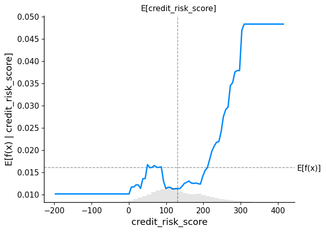

```
CPU times: total: 9min 17s
Wall time: 2min 34s
```

```python
%%time
shap.partial_dependence_plot(
    "credit_risk_score",
    lgbm.predict,
    data=X_test,
    ice=False,
    model_expected_value=True,
    feature_expected_value=True,
)
```

Este tipo de gráficos son especialmente interesantes debido a que nos permiten ver que características de determinadas variables pueden generar una mayor o menor probabilidad de fraude en nuestro modelo. Y esta variable de score de riesgo crediticio explica de gran manera dicha relación.

Se puede observar como a medida que el score de riesgo crediticio aumenta, especialmente por encima de 200, se dispara la influencia de la variable en el modelo de manera abrupta. Esto nos indica que valores altos tendrán un mayor peso en la probabilidad que asignará el modelo a la instancia, en este caso seguramente aumentando las probabilidades. Esto es muy interesante.

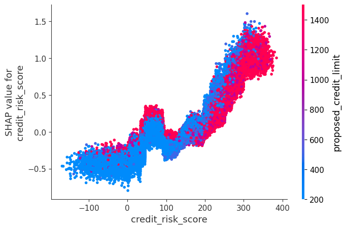

```python
shap.dependence_plot('credit_risk_score', shap_values[1], X_test)
```

Además del gráfico de dependencias parciales, la librería también ofrece gráficos de dependencia de este tipo, en donde relaciona el valor SHAP de una variable con sus valores en general y además discrimina por otra variable con la que exista cierto grado de correlación por lo que se entiende.

En este caso es muy interesante ver como, a medida que crece el score crediticio y por ende su valor shap (algo que vimos en el gráfico anterior), también suelen surgir valores más altos del límite de crédito propuesto por el usuario. Esto se torna aún más interesante cuando recordamos que en el EDA ya notamos una correlación mediana entre estas variables y este tipo de relación positiva, cosa que luego de aplicar el modelo se puede notar claramente también.

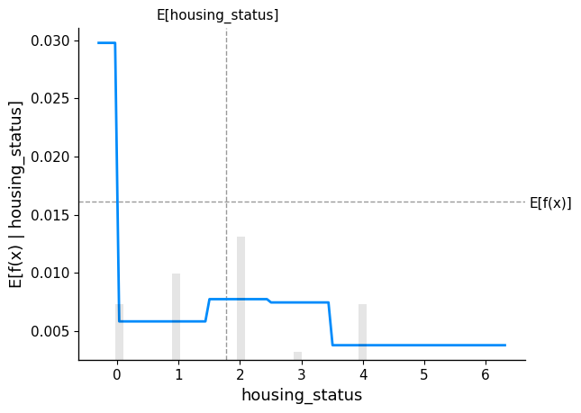

```
CPU times: total: 8min 11s
Wall time: 2min 27s
```

```python
%%time
shap.partial_dependence_plot(
    "housing_status",
    lgbm.predict,
    data=X_test,
    ice=False,
    model_expected_value=True,
    feature_expected_value=True,
)
```

No es la idea comentar todas las variables del modelo de la misma manera, pero si a variables de importancia como claramente también parece serlo Housing Status, sobre todo cuando su valor es 0, es decir que se encuentra en la categoría BA, algo que ya habíamos notado en el EDA también en su momento.

Parece que el valor 0 toma una gran preponderancia para el modelo cuando aparece y veremos que aumenta claramente las probabilidades de que exista fraude en este sentido.

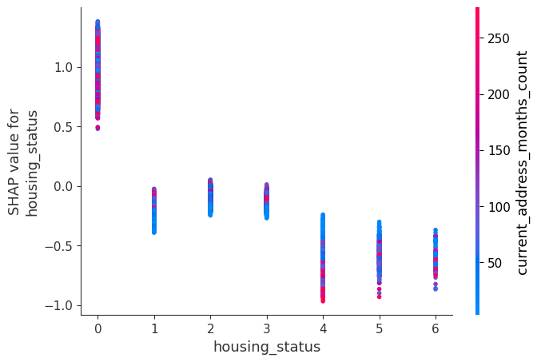

```python
shap.dependence_plot('housing_status', shap_values[1], X_test)
```

En este caso housing status se ve relacionada con los meses de antiguedad en la residencia actual del usuario, aunque en este caso la relación no es tan evidente como en el score crediticio visto con anterioridad.

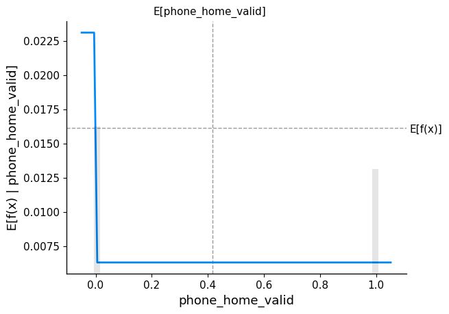

```
CPU times: total: 9min 33s
Wall time: 2min 39s
```

```python
%%time
shap.partial_dependence_plot(
    "phone_home_valid",
    lgbm.predict,
    data=X_test,
    ice=False,
    model_expected_value=True,
    feature_expected_value=True,
)
```

Otra variable importante claramente es la validez del telefono de casa proporcionado por el usuario, en este caso nuevamente resaltando cuando el valor es 0, es decir que si phone_home_valid es 0 seguramente las probabilidades de fraude se vean importantemente afectadas para la instancia en análisis.

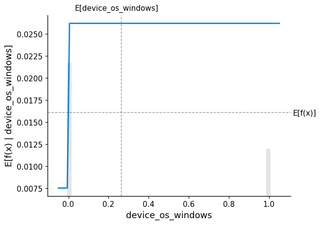

```
CPU times: total: 9min 45s
Wall time: 2min 44s
```

```python
%%time
shap.partial_dependence_plot(
    "device_os_windows",
    lgbm.predict,
    data=X_test,
    ice=False,
    model_expected_value=True,
    feature_expected_value=True,
)
```

Lo inverso a lo anterior pasa con una de las variables surgidas del OneHotEncoding. En este caso vemos que un valor de 1 en device_os_windows, es decir, cuando el dispositivo desde el que se realiza la aplicación tiene sistema operativo windows, las probabilidades se ven muy afectadas, también tendiendo hacia el fraude como veremos más adelante.

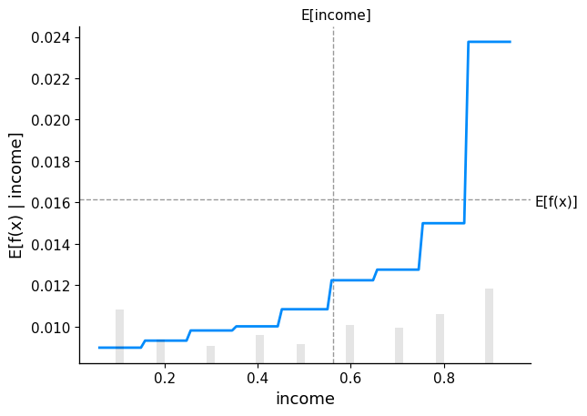

```
CPU times: total: 9min 35s
Wall time: 2min 40s
```

```python
%%time
shap.partial_dependence_plot(
    "income",
    lgbm.predict,
    data=X_test,
    ice=False,
    model_expected_value=True,
    feature_expected_value=True,
)
```

Finalmente vemos a la variable income, en donde se nota una muy clara tendencia a que mientras mayor sea el decil, mucho mayor será su preponderancia en la decisión del modelo.

Esto fue comentado en su momento en el EDA, haciendo referencia a que sería sorprendente que el income mayor significara tan claramente una mayor preponderancia al fraude. Esto puede ser así o bien puede que la codificación que se realizó para anonimizar el dataset no siga la misma estructura que como se arman los deciles por lo general y que el mayor implique un menor ingreso, cosa que a mi me sorprendería pero no descarto. Aún así, tomando los valores de la variable como los tenemos, se nota claramente esta tendencia.

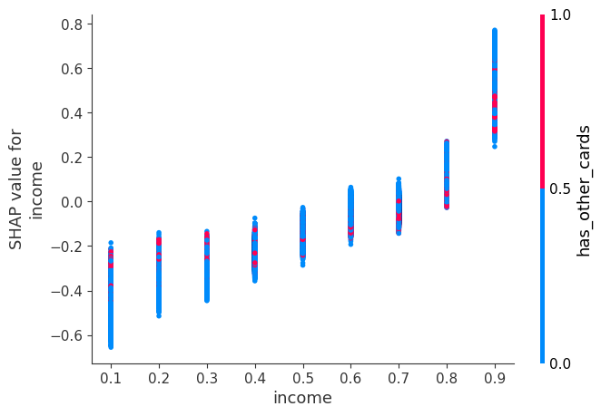

```python
shap.dependence_plot('income', shap_values[1], X_test)
```

La librería también capta una relación curiosa en este caso, mostrando no solo nuevamente como aumentan los valores shap a medida que aumenta el ingreso y viceversa cuando disminuye, sino que además podemos notar como el hecho de que los individuos NO posean otras tarjetas, es decir que la variable tienda a 0 (color azul) implica mayores valores shap y viseversa cuando si posee otras tarjetas.

# 3. Explicabilidad local por instancia

En este caso SHAP nos permite visualizar la influencia de las variables en cada instancia del DataSet y graficar dichos sucesos. Algo extremadamente interesante para nuestro análisis y que nos permite incursionar en la explicabilidad local del modelo, es decir, entendiendo porque se valora de cada manera a cada instancia

```python
shap.force_plot(explainer.expected_value[1], shap_values[1][0, :], X_test.iloc[0, :])
```

[output not shown]

En este primer caso, en donde no existía fraude, vemos como un ingreso alto, no mantener la sesión activa o no tener datos sobre meses en la residencia previa (variable que posee varios missings codificados como -1) aumentan las probabilidades de fraude. Mientras que a su vez, un alto ratio de similitud entre el nombre y el email proporcionado, el llevar varios meses en la residencia actual o que el email no sea gratuito por el contrario disminuyen la probabilidad de fraude de la aplicación en cuestión.

```python
shap.force_plot(explainer.expected_value[1], shap_values[1][2, :], X_test.iloc[2, :])
```

[output not shown]

Así podríamos estar mucho tiempo analizando instancia por instancia, pero me pareció interesante también comentar una instancia etiquetada como fraude, en la que el housing status en la categoría BA (encoding 0), el uso de windows como SO, la edad avanzada, la falta de validez en el teléfono del hogar, entre varias otras variables están generando que la probabilidad de tratarse de un fraude aumente considerablemente en este caso.

Más ejemplos:

```python
shap.force_plot(explainer.expected_value[1], shap_values[1][10, :], X_test.iloc[10, :])
```

[output not shown]

```python
shap.force_plot(explainer.expected_value[1], shap_values[1][100, :], X_test.iloc[100, :])
```

[output not shown]

# 4. Explicabilidad global del modelo

### Force Plot

Este se trata de un gráfico un poco más complejo en cuanto al entendimiento pero que puede ser muy útil, además de ser interactivo por lo que es muy interesante. Si tomamos variables como Housing Status se vuelve interesante el ver como aumentan los shap values y sobre todo como se torna de color escarlata cuando la variable tiende a tener el valor 0, el cual ya vimos que cuando aparece hace tender a la probabilidad de fraude a aumentar. Así se pueden ver todas las variables del modelo de manera interactiva.

```python
shap.force_plot(explainer.expected_value[0], shap_values[1][:100,:], features=X_test.iloc[:100, :])
```

[output not shown]

### Summary plot

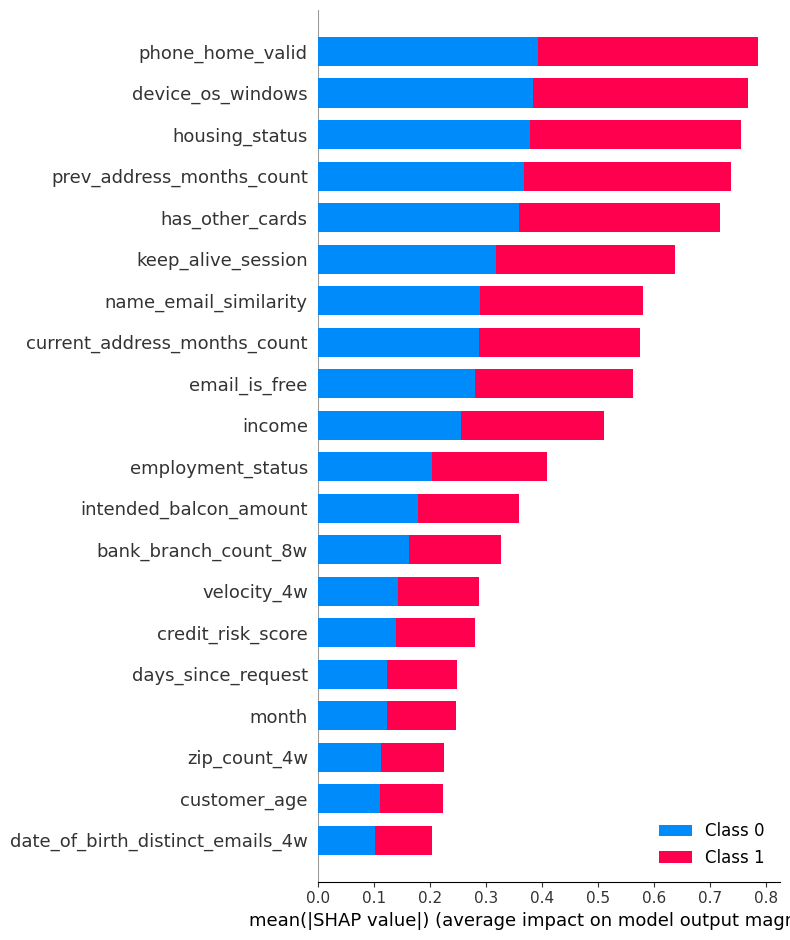

```python
shap.summary_plot(shap_values, X_test)
```

## Summary plot con direccionalidades

Llegamos finalmente al que posiblemente sea el gráfico de explicabilidad global más importante, en donde podemos observar muchas cosas valiosas juntas, como lo pueden ser el ranking de importancia de variables, que valores de esas variables hacen que aumente su poder predictivo y en que dirección lo hacen. A continuación procederemos a explicar algunas de las variables para que se entienda claramente la aplicación a nuestro caso:

- Está claro que el hecho de que la variable de **teléfono de casa válido** tenga valor bajo (0 al tratarse de una booleana), es decir, que no sea válido, claramente aumenta las probabilidades de fraude, por ello va en dirección positiva, mientras que un telefono válido (valor 1 de la variable) disminuye esas probabilidades. Algo muy similar pasa con la variable **has_other_cards**, en donde también se ve que no tener más tarjetas aumenta la proba de fraude, y sobre todo el hecho de si tenerlas lo disminuye fuertemente.
- Pasando a variables categóricas como **housing status**, tiene cierta distribución más equitativa pero se puede ver de manera muy clara como un valor totalmente bajo, seguramente de 0, que se corresponde con la categoría BA, hace que la probabilidad de fraude aumente, mientras que las categorías más altas hacen que disminuya.
- En **prev_adress_months_count** podemos ver alto interesante, y es que los valores de la variable no parecen indicar mucho en general, excepto cuando son muy bajos, que hacen tender al fraude. Esto es debido a que ese límite inferior corresponde a los valores missings codificados en -1. Es bueno saber que decidimos no imputar o eliminar esta información en su momento, ya que parece ayudar al modelo a detectar posibles fraudes.
- Algo que veíamos claro y que se confirma es que el hecho de usar sistema operativo windows aumenta la probabilidad de fraude y no usarlo la disminuye.
- Vuelve a resonar el tema del **income**, en donde se puede apreciar que mientras mayor sea el valor de la variable, más probabilidades de fraude otorga.
- Finalmente se me hace interesante ver variables continuas como la **similitud entre mail y nombre** o el **score de riesgo crediticio**. La primera aumenta la probabilidad de fraude con valores bajos (índices de relación entre nombre y mail pobres), lo cual parece razonable, mientras que con la segunda sucede lo contrario, altos score de riesgo aumentan claramente la probabilidad de fraude.

De esta manera podría seguir con todas las variables pero creo que queda bastante claro de que manera están influyendo cada una en el modelo.

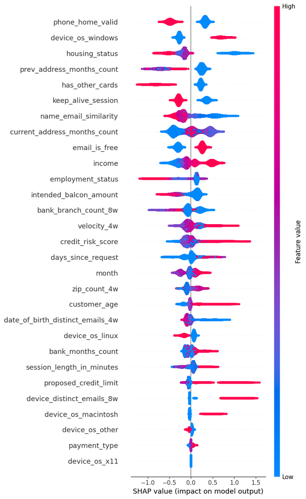

```python
shap.summary_plot(shap_values[1], features=X_test, max_display=30)
```

Todos estos aspectos nos permiten ver las variables que tienen más (y también menos) importancia para el modelo, como algunas de las que hemos mencionado.

En este sentido el análisis gráfico es muy útil, pero si queremos profundizar aún más en la búsqueda de obtener información en base al funcionamiento del modelo, es posible aplicar una técnica en la que se utilizan los shap values para generar clusters de los usuarios fraudulentos, con el fin de detectar patrones comunes entre ellos. A continuación realizaré un acercamiento de dicho procedimiento, hasta obtener los clusters para un futuro análisis.

## 5. Acercamiento al Clustering mediante shap values

```python
shap_df = pd.DataFrame(shap_values[1], columns=X_test.columns.values)
```

```python
shap_4cluster = pd.concat([shap_df, y_test], axis=1)
shap_4cluster
```

|  | income | name_email_similarity | prev_address_months_count | current_address_months_count | customer_age | days_since_request | intended_balcon_amount | payment_type | zip_count_4w | velocity_4w | bank_branch_count_8w | date_of_birth_distinct_emails_4w | employment_status | credit_risk_score | email_is_free | housing_status | phone_home_valid | bank_months_count | has_other_cards | proposed_credit_limit | session_length_in_minutes | device_os_other | device_os_linux | device_os_windows | device_os_macintosh | device_os_x11 | keep_alive_session | device_distinct_emails_8w | month | … |
| --- | --- | --- | --- | --- | --- | --- | --- | --- | --- | --- | --- | --- | --- | --- | --- | --- | --- | --- | --- | --- | --- | --- | --- | --- | --- | --- | --- | --- | --- | --- |
| 0 | 0.631093 | -0.422333 | 0.343326 | -0.338610 | -0.190710 | 0.140795 | 0.222405 | -0.012475 | 0.095046 | -0.213950 | -0.031523 | -0.020885 | 0.155845 | -0.029158 | -0.259683 | -0.158630 | 0.331285 | -0.142726 | 0.284352 | -0.058722 | -0.000794 | 0.046890 | -0.140654 | -0.239390 | -0.024565 | 0.0 | 0.354952 | -0.034989 | 0.014793 | … |
| 1 | -0.278091 | -0.339636 | 0.185981 | 0.354788 | 0.758410 | -0.020767 | 0.073126 | 0.037091 | -0.069880 | -0.078776 | 0.225030 | -0.059538 | 0.153556 | 0.118060 | -0.206685 | -0.217460 | -0.599309 | -0.024293 | -0.843052 | -0.049396 | 0.004491 | 0.025114 | -0.217868 | -0.275918 | -0.025258 | 0.0 | 0.315272 | -0.043121 | -0.246922 | … |
| 2 | -0.038119 | -0.191950 | 0.230924 | 0.154640 | 0.268490 | 0.030205 | 0.058118 | -0.002224 | 0.166862 | -0.043496 | -0.050464 | -0.099855 | 0.184808 | -0.048146 | 0.237094 | 1.020994 | 0.427374 | 0.001342 | 0.253065 | -0.026295 | -0.376566 | 0.050252 | 0.121560 | 0.552015 | -0.014919 | 0.0 | 0.309959 | -0.032524 | -0.215552 | … |
| 3 | 0.554448 | -0.149279 | -0.739288 | -0.347574 | -0.023589 | -0.077108 | 0.221342 | -0.023299 | -0.159882 | 0.158767 | 0.013050 | -0.017548 | 0.146430 | -0.040090 | 0.270542 | -0.115321 | 0.347785 | -0.201132 | 0.223082 | -0.104348 | 0.139881 | 0.083661 | -0.120216 | -0.238108 | -0.035796 | 0.0 | 0.412617 | -0.039518 | 0.073640 | … |
| 4 | 0.634118 | -0.124198 | 0.342143 | -0.424765 | -0.006418 | 0.000798 | 0.196740 | -0.018764 | -0.000135 | 0.162271 | -0.208765 | -0.008420 | -0.746508 | -0.017390 | -0.287729 | -0.157027 | 0.300540 | -0.162112 | 0.263124 | -0.041009 | -0.198784 | 0.036377 | -0.129582 | -0.248584 | -0.024212 | 0.0 | -0.273369 | -0.034691 | 0.364670 | … |
| ... | ... | ... | ... | ... | ... | ... | ... | ... | ... | ... | ... | ... | ... | ... | ... | ... | ... | ... | ... | ... | ... | ... | ... | ... | ... | ... | ... | ... | ... | … |
| 299995 | 0.088635 | -0.243719 | 0.329990 | 0.284879 | -0.034312 | 0.020250 | 0.307164 | -0.002072 | 0.174793 | 0.160119 | 0.298853 | 0.030751 | 0.161256 | -0.036049 | 0.228025 | -0.198617 | 0.373200 | 0.083626 | 0.262781 | -0.033185 | -0.015970 | -0.092780 | 0.078083 | -0.270396 | -0.026207 | 0.0 | -0.247995 | -0.037745 | 0.031436 | … |
| 299996 | 0.472983 | -0.175256 | 0.241177 | -0.323024 | 0.115588 | 0.187508 | 0.238103 | -0.022031 | 0.185333 | -0.139704 | -0.092734 | -0.094564 | 0.139236 | 0.776141 | 0.302957 | 1.008011 | 0.339050 | -0.056700 | 0.241502 | 1.096221 | 0.457213 | 0.033249 | -0.109250 | -0.278224 | -0.018038 | 0.0 | 0.336869 | -0.023292 | 0.092681 | … |
| 299997 | 0.645756 | -0.246462 | -0.796082 | -0.355679 | -0.199648 | 0.020293 | 0.105758 | -0.010450 | -0.044644 | -0.153158 | -0.040768 | -0.086904 | 0.142827 | 0.239955 | -0.234011 | -0.190430 | 0.303871 | 0.185000 | 0.212117 | 0.262589 | -0.108976 | 0.137124 | 0.089194 | 0.710978 | -0.020181 | 0.0 | 0.315581 | -0.039767 | 0.100530 | … |
| 299998 | -0.337992 | 0.547431 | 0.253658 | 0.342136 | -0.165804 | 0.022451 | 0.217504 | 0.040358 | -0.022115 | -0.145655 | -0.064353 | -0.062087 | 0.144658 | -0.153790 | 0.261026 | -0.138660 | 0.351765 | 0.073378 | -0.834538 | -0.085798 | 0.128723 | 0.036286 | -0.155167 | -0.261929 | -0.033262 | 0.0 | 0.266388 | -0.037461 | 0.048908 | … |
| 299999 | -0.054879 | -0.221231 | 0.185068 | 0.081787 | -0.073148 | 0.026133 | 0.096853 | 0.025432 | -0.127818 | -0.019714 | -0.120022 | -0.090469 | 0.152504 | 0.003868 | -0.251390 | 1.064357 | -0.590493 | -0.210859 | -0.847910 | 0.234280 | -0.050186 | 0.049148 | 0.093422 | 0.602961 | -0.011679 | 0.0 | 0.325500 | -0.034239 | -0.303737 | … |

300000 rows × 30 columns

```python
shap_4cluster.to_csv('../data/processed/shap_values_df_test.csv', index=False)
```

```python
#shap_4cluster = pd.read_csv('../data/processed/shap_values_df_test')
```

```python
shap1 = shap_4cluster[shap_4cluster['fraud_bool']==1]
```

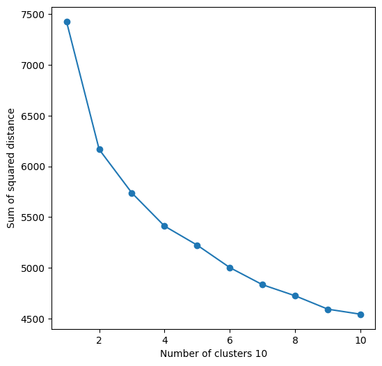

```
CPU times: total: 19.6 s
Wall time: 4.95 s
```

```python
%%time
fr.k_means_search(shap1,10)
```

```python
km = KMeans(n_clusters=3)
km.fit(shap1)
```

```
KMeans(n_clusters=3)
```

```python
km_coefs = km.transform(shap1)
```

```python
cluster = []
for i in km_coefs:
    cluster.append(i.argmax())
```

```python
km_coefs
```

```
array([[1.20892445, 0.89533217, 1.7941648 ],
       [0.96327366, 1.37713036, 1.97073677],
       [0.90958955, 1.35473041, 1.93709986],
       ...,
       [1.06067217, 1.46743865, 1.94150055],
       [1.61583138, 1.33527871, 1.98293157],
       [1.52480009, 1.74165158, 2.33388863]])
```

```python
len(cluster)
```

```
3309
```

```python
km_coefs.shape
```

```
(3309, 3)
```

```python
shap1['cluster'] = np.array(cluster) + 1 # para que el nro de clusters vaya del 1 al 3 en vez del 0 al 2
```

```python
frauds = df_fraud_test[df_fraud_test.fraud_bool==1]
frauds['cluster'] = np.array(cluster) + 1
```

```python
bools, cats, nums = fr.tipos_vars(df=frauds)
```

[output not shown]

```python
frauds.income = round(frauds.income,4)
```

```python
frauds.cluster.value_counts()
```

```
cluster
3    1919
1     787
2     603
Name: count, dtype: int64
```

La idea con este tipo de clusterización sería el realizar un análisis descriptivo que nos permita identificar patrones por los que se agrupan los usuarios que cometen fraude y tomar decisiones ya sea de prevensión, detección o reacción frente a dichas conductas.

```python
#warnings.filterwarnings('ignore')
#for i in list(frauds.columns):
#    if i in nums:
#        rf.double_plot(frauds, col_name=i, is_cont=True, target='cluster', palette=['dodgerblue','crimson','gold'], y_scale='linear')
#    elif  ((i in bools) | (i in cats)) & (i!='cluster'):
#        rf.double_plot(frauds, col_name=i, is_cont=False, target='cluster', palette=['dodgerblue','crimson','gold'], y_scale='linear')
```